# Rolling estimation of the standard deviation

Author

Zak Varty

First we load our pad with NAs function.

```r
#' Add NAs to a vector
#'
#' @param x vector to which NAs will be added
#' @param n_left number of NAs to add before x
#' @param n_right number of NAs to add after x
#'
#' @return a vector containing x with the requested number of NA values before
#'   and after
#'
#' @examples
#' pad_with_NAs(c("spider", "mouse", "cat", "dog"), n_left = 1, n_right = 2)
#' pad_with_NAs(1:5, n_left = 0, n_right = 3)
#'
pad_with_NAs <- function(x, n_left, n_right){
  c(rep(NA, n_left), x, rep(NA, n_right))
}
```

Adapting the `rolling_mean()` function to a `rolling_sd()` only requires us to alter one line of code.

```r
rolling_sd <- function(x, window_width, ...){
  # -----Input Checks ----------------------------------------------------------
  # Check that x is a vector with numerical interpretation
  stopifnot(is.logical(x) | is.integer(x) | is.double(x) | is.complex(x))
  stopifnot(length(x) > 0)

  # Check window_width is an odd, positive integer
  stopifnot(length(window_width) == 1)
  stopifnot(window_width %% 1 == 0)
  stopifnot((window_width / 2) %% 1 != 0)
  stopifnot(window_width > 0)

  # ----- Function Body --------------------------------------------------------

  # number of values left and right to include in each mean
  half_width <- floor(window_width / 2)
  x_padded <- pad_with_NAs(x, n_left = half_width, n_right = half_width)
  evaluation_locations <- seq_along(x) + half_width

  output <- rep(NA, length(x))

  for (index in evaluation_locations) {
    # Extract relevant values from x_padded
    indices_in_window <- seq(index - half_width, index + half_width, by = 1)
    values_in_window <- x_padded[indices_in_window]

    # Calculate and store standard deviation
    output[index - half_width] <- sd(values_in_window, ...)
  }

  return(output)
}
```

[figure not shown]

```r
WIDTH = 365

library(tidyverse)
library(ismev)
library(cowplot)
data("dowjones", package = "ismev")

dowjones_change <- dowjones %>%
  mutate(index_change = Index - lag(Index)) %>%
  filter(!is.na(index_change)) %>%
  mutate(sd_index_change = rolling_sd(index_change, window_width = WIDTH))

dowjones_change %>%
  ggplot(aes(x = Date, y = index_change)) +
  geom_point(col = rgb(0,0,0,0.2), size = 2) +
  geom_line(aes(y = sd_index_change), col = "darkorange", lwd = 1.5) +
  geom_vline(xintercept = as.Date("1998-06-01")) +
  ggtitle("Daily change in Dow Jones Index", "with rolling estimate of standard deviation") +
  ylab("") +
  theme_minimal() +
  theme(
    axis.text = element_text(size = 10),
    axis.title = element_text(size = 0, face = "bold", hjust = 0.98, vjust = 2),
    plot.title = element_text(size = 15, hjust = 0.02),
    plot.subtitle = element_text(size = 12, hjust = 0.02)
  )
```

It seems that the standard deviation is increasing over time - the Dow Jones index is becoming more volatile. But how confident are we in our estimates of the standard deviation?

We can add point-wise confidence bounds of ± 2 standard errors to the plot to see if we might be able to draw a horizontal line within those bounds as an approximate way of testing the significance of this finding.

The [standard error of the sample standard deviation](https://stats.stackexchange.com/q/157305) is

$$se(s) = \frac{1}{2 \sigma \sqrt{n}} \sqrt{ \left( \mu_4 - \frac{n-3}{n-1}\sigma^4\right)}$$

$$\approx \frac{1}{2 s \sqrt{n}} \sqrt{\left( \frac{1}{n}\sum_{i=1}^{n}[x_i - \bar x]^4 - \frac{n-3}{n-1}s^4\right)}.$$

We can evaluate this using the following function:

```r
std_err_of_sd <- function(x, ...){
  # calculate terms
  s <- sd(x, ...)
  mu_4_hat <- mean((x - mean(x, ...))^4)
  n <- length(x)
  a <- (n-3)/(n-1)

  # combine terms
  standard_error <- 1 / (2 * s * sqrt(n)) * sqrt(mu_4_hat - a * s ^ 4)
  return(standard_error)
}
```

This allows us to adapt the `rolling_sd()` function so that it returns a vector of point estimates if the new argument `confidence_bounds == FALSE`. Otherwise, this function returns a data frame with one column for the rolling point estimates, lower confidence bounds and upper confidence bounds.

```r
rolling_sd <- function(x, window_width, confidence_bounds = 2, ...){
# -----Input Checks ----------------------------------------------------------
  # Check that x is a vector with numerical interpretation
  stopifnot(is.logical(x) | is.integer(x) | is.double(x) | is.complex(x))
  stopifnot(length(x) > 0)

  # Check window_width is an odd, positive integer
  stopifnot(length(window_width) == 1)
  stopifnot(window_width %% 1 == 0)
  stopifnot((window_width / 2) %% 1 != 0)
  stopifnot(window_width > 0)

  # ----- Function Body --------------------------------------------------------

  # number of values left and right to include in each mean
  half_width <- floor(window_width / 2)
  x_padded <- pad_with_NAs(x, n_left = half_width, n_right = half_width)
  evaluation_locations <- seq_along(x) + half_width

  point_estimates <- rep(NA, length(x))
  standard_errors <- rep(NA, length(x))

  for (index in evaluation_locations) {
    # Extract relevant values from x_padded
    indices_in_window <- seq(index - half_width, index + half_width, by = 1)
    values_in_window <- x_padded[indices_in_window]

    # Calculate and store standard deviation
    point_estimates[index - half_width] <- sd(values_in_window, ...)
    standard_errors[index - half_width] <- std_err_of_sd(values_in_window, ...)
  }

  if (confidence_bounds == 0) {
    output <- point_estimates
    } else {
    output <- data.frame(
      point_estimate = point_estimates,
      lower_bound = point_estimates - confidence_bounds * standard_errors,
      upper_bound = point_estimates + confidence_bounds * standard_errors)
    }

  return(output)
}
```

To add these confidence bounds to our plot, we first add them as columns to `dowjones_change`.

```r
sd_estimates <- rolling_sd(
  x = dowjones_change$index_change,
  window_width = WIDTH,
  confidence_bounds = 2)

# method 1
sd_estimates$Date <- dowjones_change$Date
dowjones_change <- left_join(x = dowjones_change, y = sd_estimates, by = "Date")

## method 2
#dowjones_change <- dowjones_change %>%
#  mutate(point_estimate = sd_estimates$point_estimate) %>%
#  mutate(lower_bound = sd_estimates$lower_bound) %>%
#  mutate(upper_bound = sd_estimates$upper_bound)
```

We can then construct the plot and see that the increase in volatility does indeed seem to be significant.

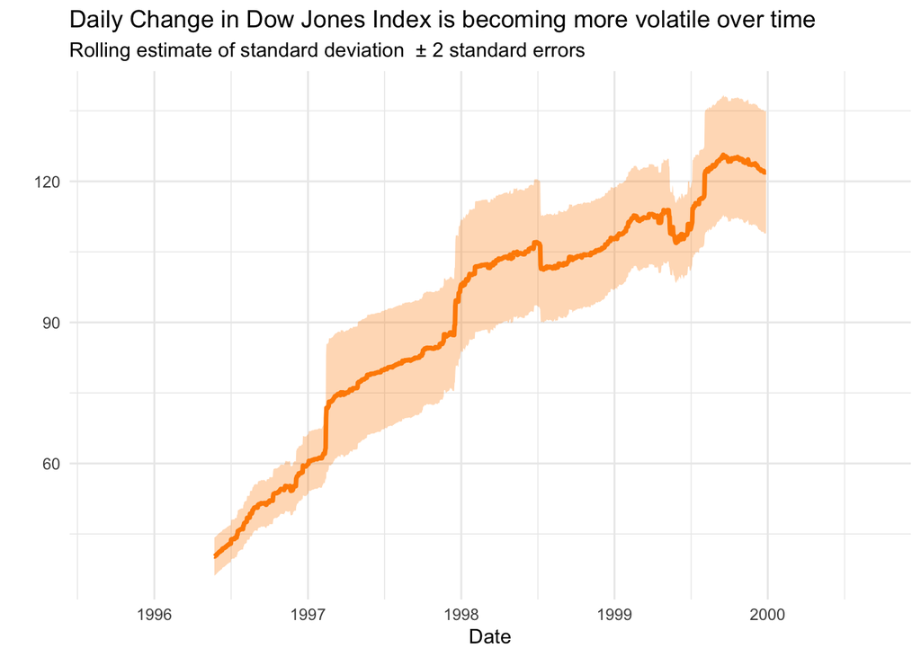

```r
ggplot(dowjones_change, aes(x = Date)) +
  geom_ribbon(
    aes(ymin = lower_bound, ymax = upper_bound),
    fill = colorspace::adjust_transparency("darkorange", 0.3)) +
  geom_line(
    aes(y = point_estimate),
    col = "darkorange",
    lwd = 1.2) +
  theme_minimal() +
  ylab("") +
  ggtitle("Daily Change in Dow Jones Index is becoming more volatile over time",
          "Rolling estimate of standard deviation  ± 2 standard errors")
```